# NYC Yellow Cab Demand Analysis

Minjee Kim

2024-12-29

# Introduction

The New York City Taxi and Limousine Commission (TLC) provides comprehensive datasets on yellow taxi trips. These datasets include details such as pickup and dropoff times, trip distances, and associated costs. This project analyzes the yellow taxi trips from August 2024, using 1 million randomly sampled rows from the 3 million original records. The goal is to identify spatio-temporal demand patterns using clustering methods that account for both spatial and temporal dynamics.

# Data Preparation and Cleaning

### Load required libraries

```r
library(dplyr)
library(wavelets)
library(reshape2)
library(tidyr)
library(lubridate)
```

```r
library(ggplot2)
library(spatstat)
library(igraph)
library(rjags)
library(fields)
library(stringr)
library(ClustGeo)
library(spdep)
library(knitr)
```

## Loading and Cleaning the Data

```r
data <- read.csv("cleaned_NYC_data.csv")

# Data Cleaning
data <- data %>%
  mutate(
    trip_id = row_number(),
    tpep_pickup_datetime = as.POSIXct(tpep_pickup_datetime, format = "%Y-%m-%d %H:%M:%S"),
    tpep_dropoff_datetime = as.POSIXct(tpep_dropoff_datetime, format = "%Y-%m-%d %H:%M:%S"),
    Duration = as.numeric(difftime(tpep_dropoff_datetime, tpep_pickup_datetime, units = "mins"))
  ) %>%
  filter(!is.na(Duration), Duration > 0)

# Removing Outliers
duration_limits <- quantile(data$Duration, probs = c(0.25, 0.75), na.rm = TRUE)
duration_iqr <- IQR(data$Duration, na.rm = TRUE)
distance_limits <- quantile(data$trip_distance, probs = c(0.25, 0.75), na.rm = TRUE)
distance_iqr <- IQR(data$trip_distance, na.rm = TRUE)

data <- data %>%
  filter(
    Duration >= (duration_limits[1] - 1.5 * duration_iqr) & Duration <= (duration_limits[2] + 1.5 * duration_iqr),
    trip_distance >= (distance_limits[1] - 1.5 * distance_iqr) & trip_distance <= (distance_limits[2] + 1.5 * distance_iqr)
  )
```

# Methodology

Taxi trips inherently consist of the pickup location (origin) and the dropoff location (destination). In this analysis, we will cluster the pickup and dropoff information separately, then match the clusters to reveal the traffic movement based on time and location to identify demand patterns such as commuting into central business districts or travel to entertainment zones.

To analyze the demand patterns, we aggregate the data into number of taxi trips into hours of the day at each taxi zone.

## Temporal Basis Functions

We used the Fourier Transform to extract temporal features from aggregated demand data. The temporal demand $f_s(t)$ at each location $s$ and time $t$ is expressed as:
$$f_s(t) = \beta_{s,0} + \sum_{k=1}^m \beta_{s,k} \cos(2\pi k t) +
\sum_{k=1}^m \gamma_{s,k} \sin(2\pi k t).$$

## Spatio-Temporal Clustering

We used the ClustGeo package for clustering, balancing temporal patterns with spatial continuity. The combined dissimilarity measure is defined as:
$$\Delta_\alpha = (1 - \alpha) D_0 + \alpha D_1,$$
where $\alpha \in [0, 1]$ controls the trade-off between temporal similarity and spatial continuity.

# Pickup and Dropoff Clustering

## Pickup Cluster

### Pickup Temporal Basis Functions

Use the Fourier Transform to extract temporal features from aggregated demand data.

```r
pickup_data <- data %>%
  select(trip_id, PU_Longitude, PU_Latitude, PULocationID, tpep_pickup_datetime) %>%
  mutate(
    pickup_hour = hour(tpep_pickup_datetime),
    pickup_day = wday(tpep_pickup_datetime, label = TRUE)
  )

hourly_demand <- pickup_data %>%
  group_by(PU_Longitude, PU_Latitude, PULocationID, pickup_hour, pickup_day) %>%
  summarize(demand = n(), .groups = "drop") %>%
  arrange(pickup_day, pickup_hour)

demand_matrix <- hourly_demand %>%
  pivot_wider(
    names_from = c(pickup_hour, pickup_day),
    values_from = demand,
    values_fill = 0
  ) %>%
  arrange(PULocationID, PU_Longitude, PU_Latitude)

## Extract Temporal Features
temporal_demand <- demand_matrix %>%
  select(-PU_Longitude, -PU_Latitude, -PULocationID)

fourier_coefficients <- apply(temporal_demand, 1, function(row) {
  fft_result <- fft(row - mean(row))  # Center data and compute FFT
  c(Re(fft_result)[1:4], Im(fft_result)[2:5])  # Extract key coefficients
}) %>% t()

colnames(fourier_coefficients) <- c("DC", "Real1", "Real2", "Real3", "Imag1", "Imag2", "Imag3", "Imag4")

fourier_data <- demand_matrix %>%
  select(PU_Longitude, PU_Latitude, PULocationID) %>%
  bind_cols(as.data.frame(fourier_coefficients))

scaled_temporal_data <- scale(as.matrix(fourier_data %>% select(-PU_Longitude, -PU_Latitude, -PULocationID)))
```

### Pickup Spatial Constraints and Clustering

Use ClustGeo to determine an appropriate alpha and perform spatio contrained temporal clustering.

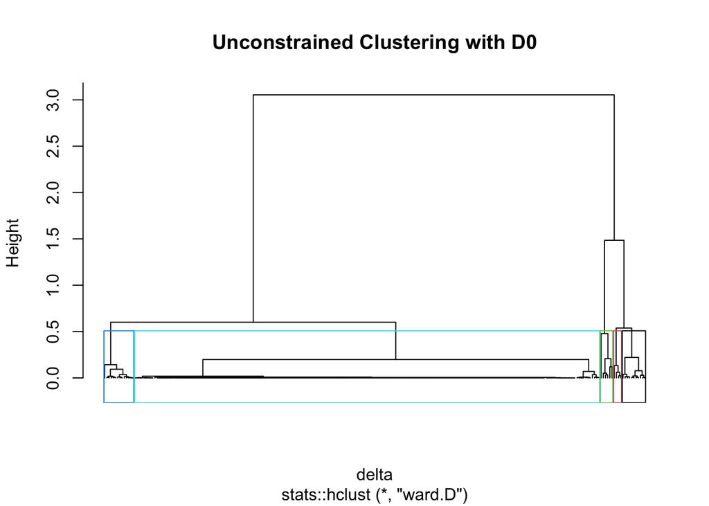

```r
coords <- as.matrix(fourier_data %>% select(PU_Longitude, PU_Latitude))
k <- 5
knn <- knearneigh(coords, k = k)
nb <- knn2nb(knn)
nb <- make.sym.nb(nb)
adj_matrix <- nb2mat(nb, style = "B", zero.policy = TRUE)
diag(adj_matrix) <- 1

D1 <- as.dist(1 - adj_matrix)
D0 <- dist(scaled_temporal_data)

tree_unconstrained <- hclustgeo(D0)
plot(tree_unconstrained, hang = -1, label = FALSE, main = "Unconstrained Clustering with D0")
rect.hclust(tree_unconstrained, k = 5, border = c(4, 5, 3, 2, 1))
```

```r
range_alpha <- seq(0, 1, 0.1)
K <- 5

png("pickup_alpha_eval.png", width = 500, height = 500, res = 120)
cr <- choicealpha(D0, D1, range.alpha = range_alpha, K = K, graph = TRUE)
dev.off()
```

```r
alpha <- 0.2
tree_constrained <- hclustgeo(D0, D1, alpha = alpha)
P5 <- cutree(tree_constrained, k = 5)

fourier_data <- fourier_data %>%
  mutate(cluster = P5)

# Save pickup cluster to pickup_data
fourier_cluster <- fourier_data %>% select(PULocationID, cluster)
pickup_data <- merge(pickup_data, fourier_cluster, by = "PULocationID")
```

### Pickup Cluster Visualization

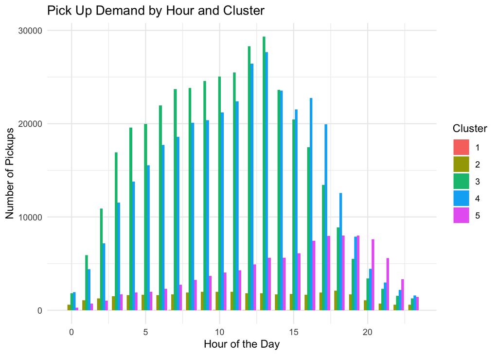

```r
ggplot(pickup_data , aes(x = pickup_hour, fill = factor(cluster))) +
  geom_bar(position = "dodge") +
  labs(
    title = "Pick Up Demand by Hour and Cluster",
    x = "Hour of the Day",
    y = "Number of Pickups",
    fill = "Cluster"
  ) +
  theme_minimal()
```

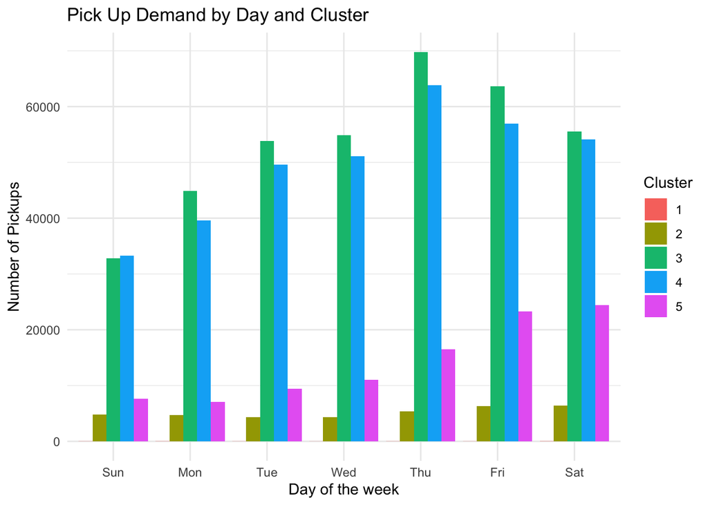

```r
ggplot(pickup_data , aes(x = pickup_day, fill = factor(cluster))) +
  geom_bar(position = "dodge") +
  labs(
    title = "Pick Up Demand by Day and Cluster",
    x = "Day of the week",
    y = "Number of Pickups",
    fill = "Cluster"
  ) +
  theme_minimal()
```

## Dropoff Cluster

Carry the same analysis as pickup data clustering.

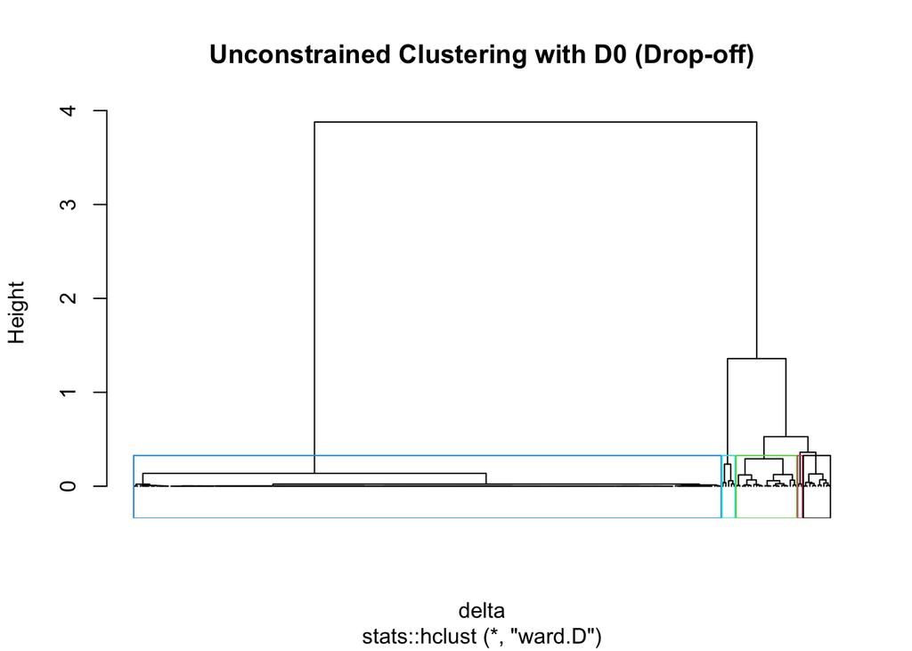

```r
dropoff_data <- data %>%
  select(trip_id, DO_Longitude, DO_Latitude, DOLocationID, tpep_dropoff_datetime) %>%
  mutate(
    dropoff_hour = hour(tpep_dropoff_datetime),
    dropoff_day = wday(tpep_dropoff_datetime, label = TRUE)
  )

hourly_demand_dropoff <- dropoff_data %>%
  group_by(DO_Longitude, DO_Latitude, DOLocationID, dropoff_hour, dropoff_day) %>%
  summarize(demand = n(), .groups = "drop") %>%
  arrange(dropoff_day, dropoff_hour)

demand_matrix_dropoff <- hourly_demand_dropoff %>%
  pivot_wider(
    names_from = c(dropoff_hour, dropoff_day),
    values_from = demand,
    values_fill = 0
  ) %>%
  arrange(DOLocationID, DO_Longitude, DO_Latitude)

temporal_demand_dropoff <- demand_matrix_dropoff %>%
  select(-DO_Longitude, -DO_Latitude, -DOLocationID)

fourier_coefficients_dropoff <- apply(temporal_demand_dropoff, 1, function(row) {
  fft_result <- fft(row - mean(row))  # Center data and compute FFT
  c(Re(fft_result)[1:4], Im(fft_result)[2:5])  # Extract key coefficients
}) %>% t()

colnames(fourier_coefficients_dropoff) <- c("DC", "Real1", "Real2", "Real3", "Imag1", "Imag2", "Imag3", "Imag4")

fourier_data_dropoff <- demand_matrix_dropoff %>%
  select(DO_Longitude, DO_Latitude, DOLocationID) %>%
  bind_cols(as.data.frame(fourier_coefficients_dropoff))

scaled_temporal_data_dropoff <- scale(as.matrix(fourier_data_dropoff %>% select(-DO_Longitude, -DO_Latitude, -DOLocationID)))

coords_dropoff <- as.matrix(fourier_data_dropoff %>% select(DO_Longitude, DO_Latitude))
k <- 5
knn_dropoff <- knearneigh(coords_dropoff, k = k)
nb_dropoff <- knn2nb(knn_dropoff)
nb_dropoff <- make.sym.nb(nb_dropoff)
adj_matrix_dropoff <- nb2mat(nb_dropoff, style = "B", zero.policy = TRUE)
diag(adj_matrix_dropoff) <- 1

D1_dropoff <- as.dist(1 - adj_matrix_dropoff)
D0_dropoff <- dist(scaled_temporal_data_dropoff)

tree_unconstrained_dropoff <- hclustgeo(D0_dropoff)
plot(tree_unconstrained_dropoff, hang = -1, label = FALSE, main = "Unconstrained Clustering with D0 (Drop-off)")
rect.hclust(tree_unconstrained_dropoff, k = 5, border = c(4, 5, 3, 2, 1))
```

```r
range_alpha <- seq(0, 1, 0.1)
K <- 5

png("dropoff_alpha_eval.png", width = 500, height = 500, res = 120)
cr <- choicealpha(D0 = D0_dropoff, D1 = D1_dropoff, range.alpha = range_alpha, K = K, graph = TRUE)
dev.off()
```

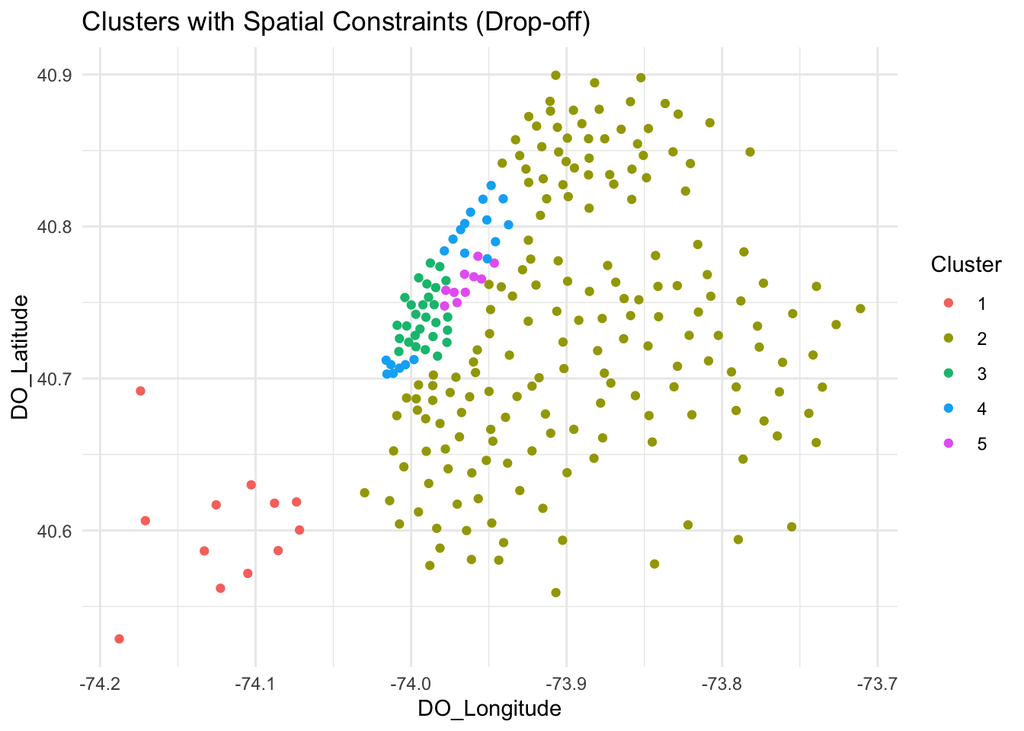

```r
alpha <- 0.2
tree_constrained_dropoff <- hclustgeo(D0_dropoff, D1_dropoff, alpha = alpha)
P5_dropoff <- cutree(tree_constrained_dropoff, k = 5)

fourier_data_dropoff <- fourier_data_dropoff %>%
  mutate(cluster = P5_dropoff)

ggplot(fourier_data_dropoff, aes(x = DO_Longitude, y = DO_Latitude, color = as.factor(cluster))) +
  geom_point() +
  labs(title = "Clusters with Spatial Constraints (Drop-off)", color = "Cluster") +
  theme_minimal()
```

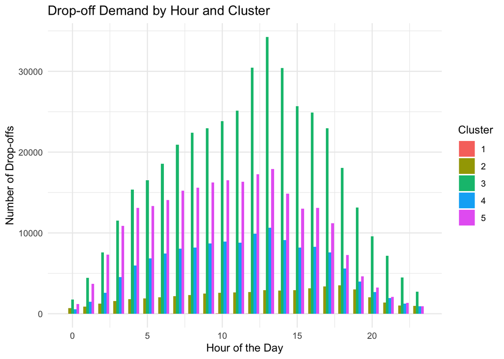

```r
fourier_dropoff_cluster <- fourier_data_dropoff %>% select(DOLocationID, cluster)

dropoff_data <- merge(dropoff_data, fourier_dropoff_cluster, by = "DOLocationID")

ggplot(dropoff_data, aes(x = dropoff_hour, fill = factor(cluster))) +
  geom_bar(position = "dodge") +
  labs(
    title = "Drop-off Demand by Hour and Cluster",
    x = "Hour of the Day",
    y = "Number of Drop-offs",
    fill = "Cluster"
  ) +
  theme_minimal()
```

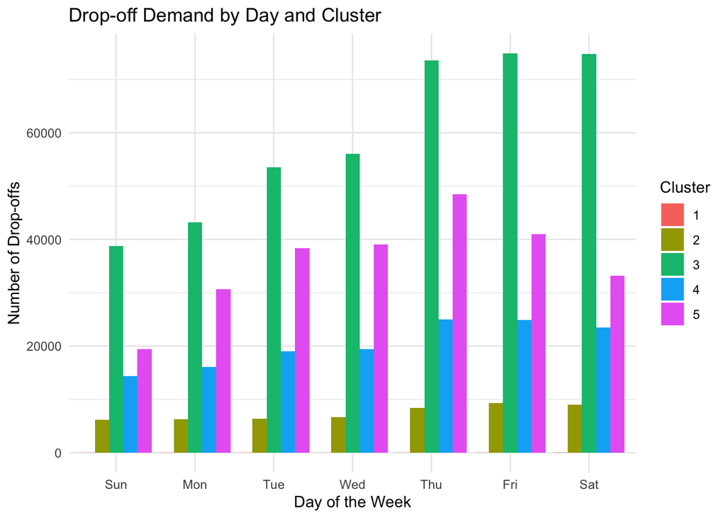

```r
ggplot(dropoff_data, aes(x = dropoff_day, fill = factor(cluster))) +
  geom_bar(position = "dodge") +
  labs(
    title = "Drop-off Demand by Day and Cluster",
    x = "Day of the Week",
    y = "Number of Drop-offs",
    fill = "Cluster"
  ) +
  theme_minimal()
```

# Results: Traffic Flow Analysis

## Matching the Clusters

```r
data_with_clusters <- data %>%
  left_join(pickup_data %>% select(trip_id, pickup_cluster = cluster), by = "trip_id") %>%
  left_join(dropoff_data %>% select(trip_id, dropoff_cluster = cluster), by = "trip_id")

traffic_flow <- data_with_clusters %>%
  group_by(pickup_cluster, dropoff_cluster) %>%
  summarize(flow_count = n(), .groups = "drop")

arrange(traffic_flow, desc(flow_count))
```

```
## # A tibble: 21 × 3
##    pickup_cluster dropoff_cluster flow_count
##             <int>           <int>      <int>
##  1              4               3     199527
##  2              3               3     146144
##  3              3               5     142982
##  4              4               5      88819
##  5              3               4      75719
##  6              5               3      66672
##  7              4               4      53443
##  8              2               2      30581
##  9              5               5      17219
## 10              5               4      11063
## # ℹ 11 more rows
```

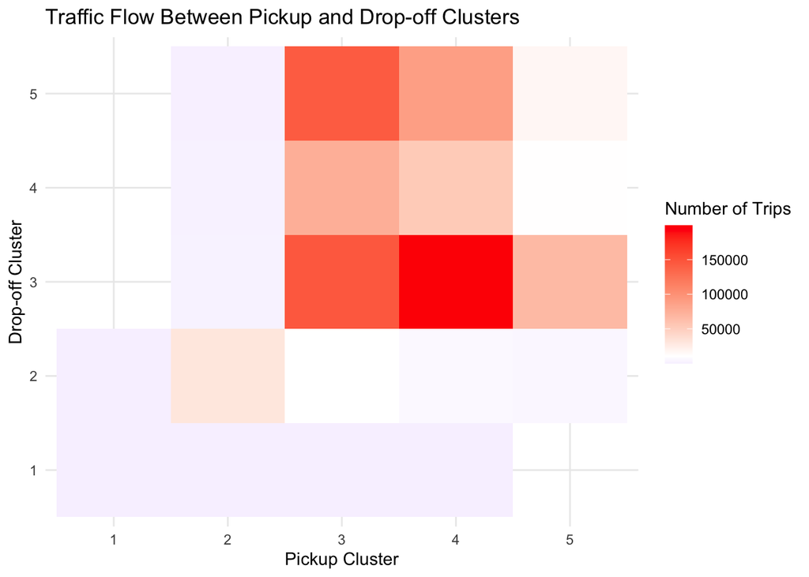

```r
ggplot(traffic_flow, aes(x = as.factor(pickup_cluster), y = as.factor(dropoff_cluster), fill = flow_count)) +
  geom_tile() +
  scale_fill_gradient2(low = "blue", mid = "white", high = "red", midpoint = median(traffic_flow$flow_count)) +
  labs(
    title = "Traffic Flow Between Pickup and Drop-off Clusters",
    x = "Pickup Cluster",
    y = "Drop-off Cluster",
    fill = "Number of Trips"
  ) +
  theme_minimal()
```

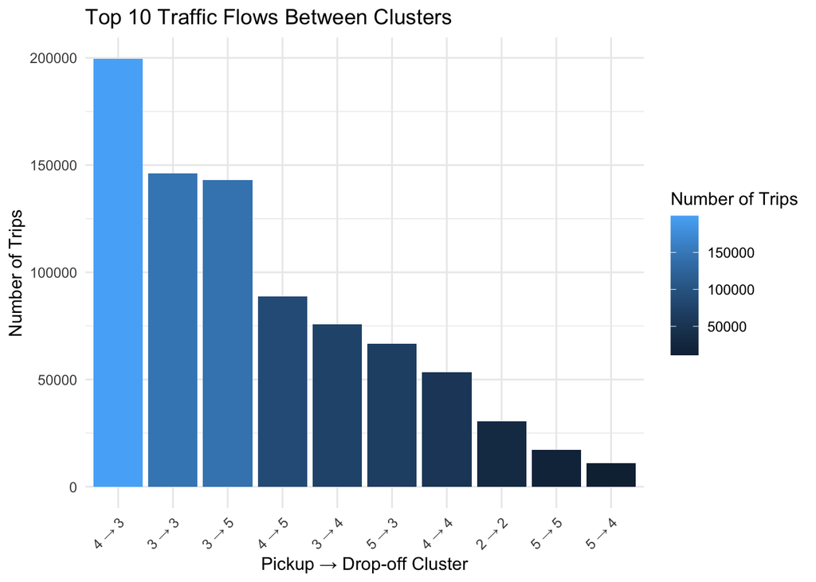

```r
top_traffic_flows <- traffic_flow %>%
  arrange(desc(flow_count)) %>%
  slice(1:3)

data_top_flows <- data_with_clusters %>%
  semi_join(top_traffic_flows, by = c("pickup_cluster", "dropoff_cluster"))

top_traffic_flows <- data_top_flows %>%
  group_by(pickup_cluster, dropoff_cluster) %>%
  summarize(
    avg_trip_distance = round(mean(trip_distance, na.rm = TRUE), 3),
    median_trip_distance = round(median(trip_distance, na.rm = TRUE), 3),
    avg_passenger_count = round(mean(passenger_count, na.rm = TRUE), 3),
    avg_fare_amount = round(mean(fare_amount, na.rm = TRUE), 3),
    avg_duration = round(mean(Duration, na.rm = TRUE), 3),
    total_trips = n(),
    .groups = "drop"
  )

top_flows <- traffic_flow %>%
  arrange(desc(flow_count)) %>%
  head(10)

ggplot(top_flows, aes(x = reorder(paste(pickup_cluster, dropoff_cluster, sep = " → "), -flow_count), y = flow_count, fill = flow_count)) +
  geom_bar(stat = "identity") +
  labs(
    title = "Top 10 Traffic Flows Between Clusters",
    x = "Pickup → Drop-off Cluster",
    y = "Number of Trips",
    fill = "Number of Trips"
  ) +
  theme_minimal() +
  theme(axis.text.x = element_text(angle = 45, hjust = 1))
```

```r
top_traffic_flows <- data_top_flows %>%
  group_by(pickup_cluster, dropoff_cluster) %>%
  summarize(
    avg_trip_distance = round(mean(trip_distance, na.rm = TRUE), 3),
    median_trip_distance = round(median(trip_distance, na.rm = TRUE), 3),
    avg_passenger_count = round(mean(passenger_count, na.rm = TRUE), 3),
    avg_fare_amount = round(mean(fare_amount, na.rm = TRUE), 3),
    avg_duration = round(mean(Duration, na.rm = TRUE), 3),
    total_trips = n(),
    .groups = "drop"
  )


kable(top_traffic_flows, format = "latex", booktabs = TRUE, digits = 3,
      col.names = c(
        "Pickup Cluster",
        "Dropoff Cluster",
        "Avg Trip Distance (miles)",
        "Median Trip Distance (miles)",
        "Avg Passenger Count",
        "Avg Fare Amount ($)",
        "Avg Duration (mins)",
        "Total Trips"
      ),
      caption = "Summary Statistics for Top 3 Traffic Flows")
```

[output not shown]

### Traffic Into Manhattan

To examine the traffic into Manhattan, we can consider the trips from pickup clusters 1,2 (outside of Manhattan) to dropoff clusters 3,4,5 (within Manhattan).

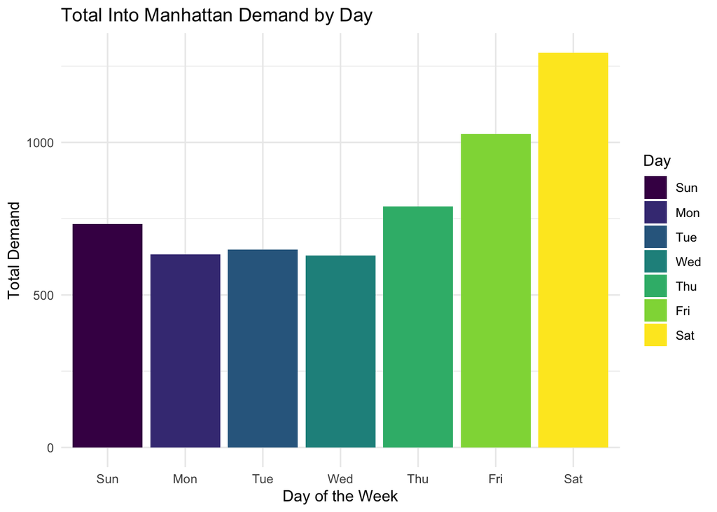

```r
hourly_demand_into_city <- data_with_clusters %>%
  filter(pickup_cluster %in% c(1, 2), dropoff_cluster %in% c(3, 4, 5)) %>%
  select(trip_id, PU_Longitude, PU_Latitude, PULocationID, tpep_pickup_datetime) %>%
  mutate(
    pickup_hour = hour(tpep_pickup_datetime),
    pickup_day = wday(tpep_pickup_datetime, label = TRUE)
  ) %>%
  group_by(PU_Longitude, PU_Latitude, PULocationID, pickup_hour, pickup_day) %>%
  summarize(demand = n(), .groups = "drop")

demand_matrix_into_city <- hourly_demand_into_city %>%
  pivot_wider(
    names_from = c(pickup_hour, pickup_day),
    values_from = demand,
    values_fill = 0
  ) %>%
  arrange(PULocationID, PU_Longitude, PU_Latitude)

daily_demand_into_city <- hourly_demand_into_city %>%
  group_by(pickup_day) %>%
  summarize(total_demand = sum(demand), .groups = "drop")

ggplot(daily_demand_into_city, aes(x = pickup_day, y = total_demand, fill = pickup_day)) +
  geom_bar(stat = "identity") +
  labs(
    title = "Total Into Manhattan Demand by Day",
    x = "Day of the Week",
    y = "Total Demand",
    fill = "Day"
  ) +
  theme_minimal()
```

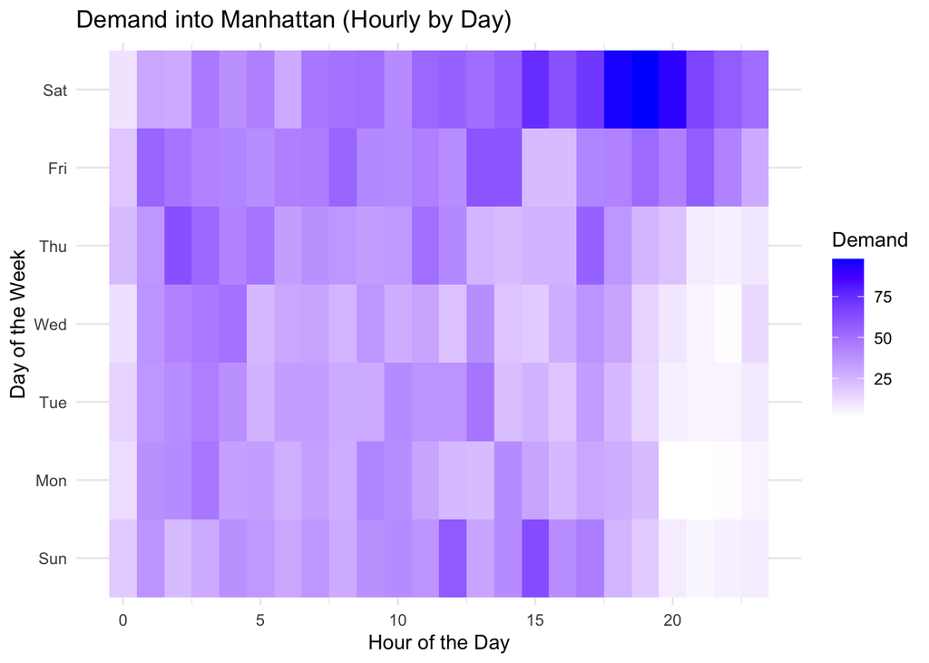

```r
hourly_heatmap_data <- hourly_demand_into_city %>%
  group_by(pickup_hour, pickup_day) %>%
  summarize(total_demand = sum(demand), .groups = "drop")

ggplot(hourly_heatmap_data, aes(x = pickup_hour, y = pickup_day, fill = total_demand)) +
  geom_tile() +
  scale_fill_gradient(low = "white", high = "blue") +
  labs(
    title = "Demand into Manhattan (Hourly by Day)",
    x = "Hour of the Day",
    y = "Day of the Week",
    fill = "Demand"
  ) +
  theme_minimal()
```

### Out of Manhattan

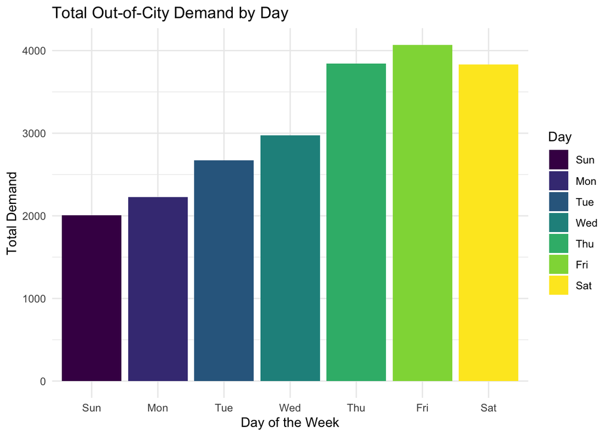

```r
hourly_demand_out_of_city <- data_with_clusters %>%
  filter(pickup_cluster %in% c(3, 4, 5), dropoff_cluster %in% c(1, 2)) %>%
  select(trip_id, PU_Longitude, PU_Latitude, PULocationID, tpep_pickup_datetime) %>%
  mutate(
    pickup_hour = hour(tpep_pickup_datetime),
    pickup_day = wday(tpep_pickup_datetime, label = TRUE)
  ) %>%
  group_by(PU_Longitude, PU_Latitude, PULocationID, pickup_hour, pickup_day) %>%
  summarize(demand = n(), .groups = "drop")

demand_matrix_out_of_city <- hourly_demand_out_of_city %>%
  pivot_wider(
    names_from = c(pickup_hour, pickup_day),
    values_from = demand,
    values_fill = 0
  ) %>%
  arrange(PULocationID, PU_Longitude, PU_Latitude)
daily_demand_out_of_city <- hourly_demand_out_of_city %>%
  group_by(pickup_day) %>%
  summarize(total_demand = sum(demand), .groups = "drop")

ggplot(daily_demand_out_of_city, aes(x = pickup_day, y = total_demand, fill = pickup_day)) +
  geom_bar(stat = "identity") +
  labs(
    title = "Total Out-of-City Demand by Day",
    x = "Day of the Week",
    y = "Total Demand",
    fill = "Day"
  ) +
  theme_minimal()
```

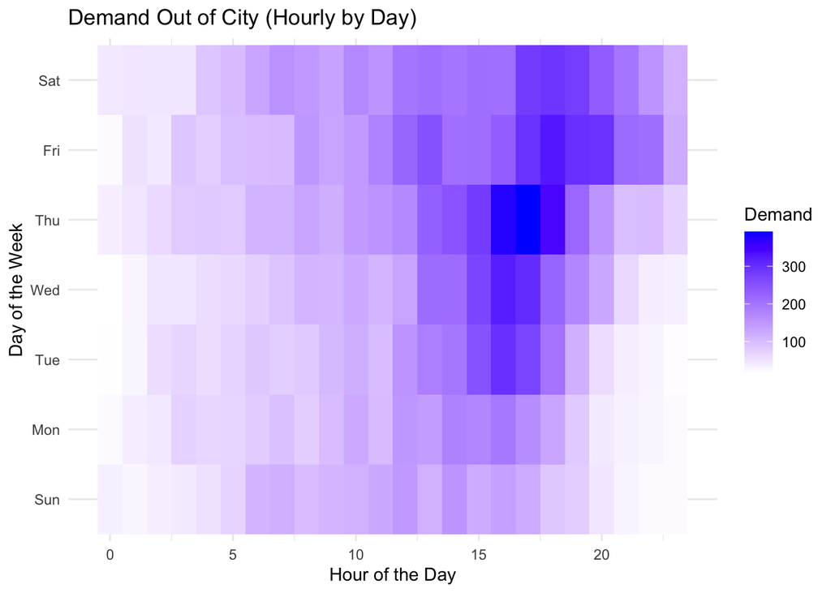

```r
hourly_heatmap_out_of_city <- hourly_demand_out_of_city %>%
  group_by(pickup_hour, pickup_day) %>%
  summarize(total_demand = sum(demand), .groups = "drop")

# Plot hourly heatmap
ggplot(hourly_heatmap_out_of_city, aes(x = pickup_hour, y = pickup_day, fill = total_demand)) +
  geom_tile() +
  scale_fill_gradient(low = "white", high = "blue") +
  labs(
    title = "Demand Out of City (Hourly by Day)",
    x = "Hour of the Day",
    y = "Day of the Week",
    fill = "Demand"
  ) +
  theme_minimal()
```

### Within Manhattan

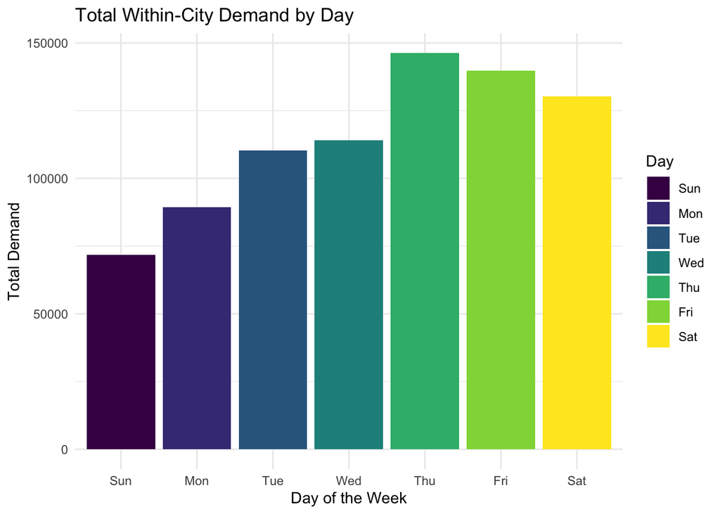

```r
hourly_demand_within_city <- data_with_clusters %>%
  filter(pickup_cluster %in% c(3, 4, 5), dropoff_cluster %in% c(3, 4, 5)) %>%
  select(trip_id, PU_Longitude, PU_Latitude, PULocationID, tpep_pickup_datetime) %>%
  mutate(
    pickup_hour = hour(tpep_pickup_datetime),
    pickup_day = wday(tpep_pickup_datetime, label = TRUE)
  ) %>%
  group_by(PU_Longitude, PU_Latitude, PULocationID, pickup_hour, pickup_day) %>%
  summarize(demand = n(), .groups = "drop")

demand_matrix_within_city <- hourly_demand_within_city %>%
  pivot_wider(
    names_from = c(pickup_hour, pickup_day),
    values_from = demand,
    values_fill = 0
  ) %>%
  arrange(PULocationID, PU_Longitude, PU_Latitude)

daily_demand_within_city <- hourly_demand_within_city %>%
  group_by(pickup_day) %>%
  summarize(total_demand = sum(demand), .groups = "drop")

ggplot(daily_demand_within_city, aes(x = pickup_day, y = total_demand, fill = pickup_day)) +
  geom_bar(stat = "identity") +
  labs(
    title = "Total Within-City Demand by Day",
    x = "Day of the Week",
    y = "Total Demand",
    fill = "Day"
  ) +
  theme_minimal()
```

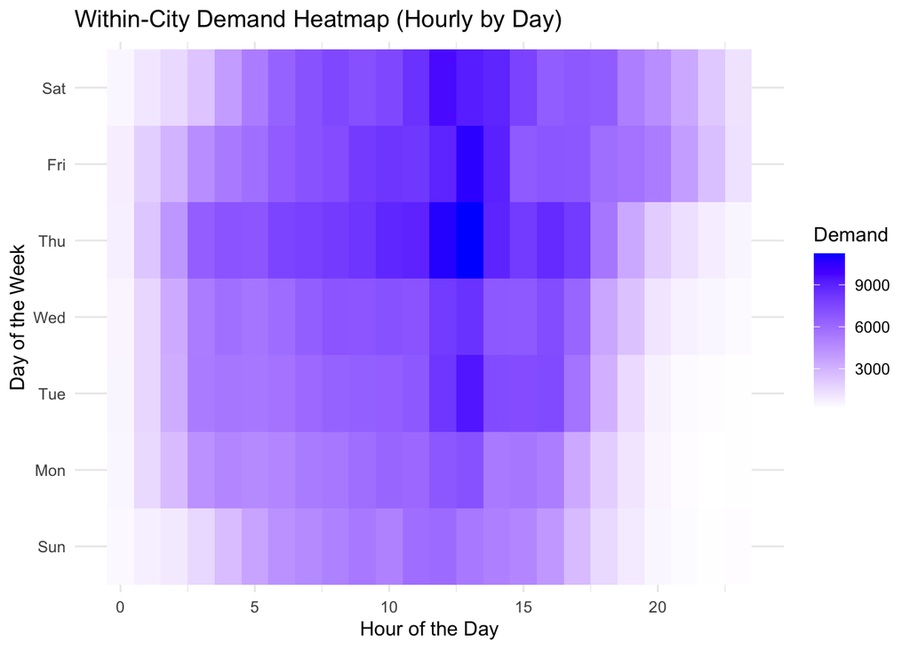

```r
hourly_heatmap_within_city <- hourly_demand_within_city %>%
  group_by(pickup_hour, pickup_day) %>%
  summarize(total_demand = sum(demand), .groups = "drop")

ggplot(hourly_heatmap_within_city, aes(x = pickup_hour, y = pickup_day, fill = total_demand)) +
  geom_tile() +
  scale_fill_gradient(low = "white", high = "blue") +
  labs(
    title = "Within-City Demand Heatmap (Hourly by Day)",
    x = "Hour of the Day",
    y = "Day of the Week",
    fill = "Demand"
  ) +
  theme_minimal()
```

## Summary Statistics

```r
into_city_summary <- data_with_clusters %>%
  filter(pickup_cluster %in% c(1, 2), dropoff_cluster %in% c(3, 4, 5)) %>%
  group_by(pickup_cluster, dropoff_cluster) %>%
  summarize(
    avg_trip_distance = round(mean(trip_distance, na.rm = TRUE), 3),
    median_trip_distance = round(median(trip_distance, na.rm = TRUE), 3),
    avg_passenger_count = round(mean(passenger_count, na.rm = TRUE), 3),
    avg_fare_amount = round(mean(fare_amount, na.rm = TRUE), 3),
    avg_duration = round(mean(Duration, na.rm = TRUE), 3),
    total_trips = n(),
    .groups = "drop"
  )
out_of_city_summary <- data_with_clusters %>%
  filter(pickup_cluster %in% c(3, 4, 5), dropoff_cluster %in% c(1, 2)) %>%
  group_by(pickup_cluster, dropoff_cluster) %>%
  summarize(
    avg_trip_distance = round(mean(trip_distance, na.rm = TRUE), 3),
    median_trip_distance = round(median(trip_distance, na.rm = TRUE), 3),
    avg_passenger_count = round(mean(passenger_count, na.rm = TRUE), 3),
    avg_fare_amount = round(mean(fare_amount, na.rm = TRUE), 3),
    avg_duration = round(mean(Duration, na.rm = TRUE), 3),
    total_trips = n(),
    .groups = "drop"
  )

within_city_summary <- data_with_clusters %>%
  filter(pickup_cluster %in% c(3, 4, 5), dropoff_cluster %in% c(3, 4, 5)) %>%
  group_by(pickup_cluster, dropoff_cluster) %>%
  summarize(
    avg_trip_distance = round(mean(trip_distance, na.rm = TRUE), 3),
    median_trip_distance = round(median(trip_distance, na.rm = TRUE), 3),
    avg_passenger_count = round(mean(passenger_count, na.rm = TRUE), 3),
    avg_fare_amount = round(mean(fare_amount, na.rm = TRUE), 3),
    avg_duration = round(mean(Duration, na.rm = TRUE), 3),
    total_trips = n(),
    .groups = "drop"
  )



into_city_summary_stats <- into_city_summary %>%
  summarize(
    avg_trip_distance_mean = mean(avg_trip_distance, na.rm = TRUE),
    avg_trip_distance_sd = sd(avg_trip_distance, na.rm = TRUE),
    avg_fare_amount_mean = mean(avg_fare_amount, na.rm = TRUE),
    avg_fare_amount_sd = sd(avg_fare_amount, na.rm = TRUE),
    avg_duration_mean = mean(avg_duration, na.rm = TRUE),
    avg_duration_sd = sd(avg_duration, na.rm = TRUE),
    avg_passenger_count_mean = mean(avg_passenger_count, na.rm = TRUE),
    avg_passenger_count_sd = sd(avg_passenger_count, na.rm = TRUE),
    total_trips_mean = sum(total_trips, na.rm = TRUE)
  )

out_of_city_summary_stats <- out_of_city_summary%>%
  summarize(
    avg_trip_distance_mean = mean(avg_trip_distance, na.rm = TRUE),
    avg_trip_distance_sd = sd(avg_trip_distance, na.rm = TRUE),
    avg_fare_amount_mean = mean(avg_fare_amount, na.rm = TRUE),
    avg_fare_amount_sd = sd(avg_fare_amount, na.rm = TRUE),
    avg_duration_mean = mean(avg_duration, na.rm = TRUE),
    avg_duration_sd = sd(avg_duration, na.rm = TRUE),
    avg_passenger_count_mean = mean(avg_passenger_count, na.rm = TRUE),
    avg_passenger_count_sd = sd(avg_passenger_count, na.rm = TRUE),
    total_trips_mean = sum(total_trips, na.rm = TRUE)
  )



within_city_summary_stats <- within_city_summary %>%
  summarize(
    avg_trip_distance_mean = mean(avg_trip_distance, na.rm = TRUE),
    avg_trip_distance_sd = sd(avg_trip_distance, na.rm = TRUE),
    avg_fare_amount_mean = mean(avg_fare_amount, na.rm = TRUE),
    avg_fare_amount_sd = sd(avg_fare_amount, na.rm = TRUE),
    avg_duration_mean = mean(avg_duration, na.rm = TRUE),
    avg_duration_sd = sd(avg_duration, na.rm = TRUE),
    avg_passenger_count_mean = mean(avg_passenger_count, na.rm = TRUE),
    avg_passenger_count_sd = sd(avg_passenger_count, na.rm = TRUE),
    total_trips_mean = sum(total_trips, na.rm = TRUE)
  )

combined_summary_stats <- bind_rows(
  into_city_summary %>% mutate(type = "Into City"),
  out_of_city_summary %>% mutate(type = "Out of City"),
  within_city_summary %>% mutate(type = "Within City")
)

kable(combined_summary_stats, format = "html", booktabs = TRUE, caption = "Combined Summary of Traffic Flows")
```

Combined Summary of Traffic Flows

| pickup_cluster | dropoff_cluster | avg_trip_distance | median_trip_distance | avg_passenger_count | avg_fare_amount | avg_duration | total_trips | type |
| --- | --- | --- | --- | --- | --- | --- | --- | --- |
| 2 | 3 | 4.264 | 4.280 | 1.385 | 26.889 | 22.079 | 2534 | Into City |
| 2 | 4 | 4.517 | 5.025 | 1.251 | 24.687 | 19.448 | 1986 | Into City |
| 2 | 5 | 4.624 | 5.000 | 1.315 | 28.274 | 21.754 | 1235 | Into City |
| 3 | 1 | 0.460 | 0.000 | 1.000 | 39.775 | 22.646 | 4 | Out of City |
| 3 | 2 | 4.329 | 4.310 | 1.274 | 23.030 | 20.401 | 10453 | Out of City |
| 4 | 1 | 3.712 | 4.075 | 2.333 | 57.123 | 24.438 | 4 | Out of City |
| 4 | 2 | 5.255 | 5.370 | 1.305 | 27.290 | 24.913 | 6605 | Out of City |
| 5 | 2 | 4.109 | 3.940 | 1.310 | 22.328 | 20.317 | 4559 | Out of City |
| 3 | 3 | 2.173 | 1.860 | 1.333 | 15.179 | 14.475 | 146144 | Within City |
| 3 | 4 | 1.953 | 1.530 | 1.291 | 12.889 | 10.605 | 75719 | Within City |
| 3 | 5 | 1.454 | 1.150 | 1.260 | 11.037 | 9.613 | 142982 | Within City |
| 4 | 3 | 1.490 | 1.290 | 1.389 | 12.263 | 11.730 | 199527 | Within City |
| 4 | 4 | 2.911 | 2.700 | 1.377 | 17.086 | 15.282 | 53443 | Within City |
| 4 | 5 | 1.638 | 1.500 | 1.323 | 13.017 | 12.956 | 88819 | Within City |
| 5 | 3 | 1.575 | 1.360 | 1.419 | 11.925 | 10.925 | 66672 | Within City |
| 5 | 4 | 3.297 | 2.790 | 1.404 | 18.517 | 16.328 | 11063 | Within City |
| 5 | 5 | 2.988 | 2.800 | 1.410 | 17.833 | 16.684 | 17219 | Within City |

## References

1. NYC Taxi Zones Dataset, available at [NYC Open Data Portal](https://data.cityofnewyork.us), 2024.
2. ClustGeo Package Documentation, available at [CRAN](https://cran.r-project.org/web/packages/ClustGeo), 2024.